#### Project Objective

The objective of this assignment is to analyse the *iris* dataset using R programming language for data manipulation, exploration, and analysis tasks including handling missing values, outliers, correlation analysis, linear regression, and hypothesis testing.

### INSTALL AND LOAD LIBRARIES

```r
# install.packages("ggplot2", dependencies=TRUE)
# install.packages("dplyr")
# install.packages("tidyr")
# install.packages("data.table")
```

```r
library(ggplot2)
library(dplyr)
library(tidyr)
library(data.table)
```

### LOAD DATA

```r
iris
```

```
##     Sepal.Length Sepal.Width Petal.Length Petal.Width    Species
## 1            5.1         3.5          1.4         0.2     setosa
## 2            4.9         3.0          1.4         0.2     setosa
## 3            4.7         3.2          1.3         0.2     setosa
## 4            4.6         3.1          1.5         0.2     setosa
## 5            5.0         3.6          1.4         0.2     setosa
## 6            5.4         3.9          1.7         0.4     setosa
## 7            4.6         3.4          1.4         0.3     setosa
## 8            5.0         3.4          1.5         0.2     setosa
## 9            4.4         2.9          1.4         0.2     setosa
## 10           4.9         3.1          1.5         0.1     setosa
## 11           5.4         3.7          1.5         0.2     setosa
## 12           4.8         3.4          1.6         0.2     setosa
## 13           4.8         3.0          1.4         0.1     setosa
## 14           4.3         3.0          1.1         0.1     setosa
```

[output cut: 136 more lines]

```r
head(iris)
```

```
##   Sepal.Length Sepal.Width Petal.Length Petal.Width Species
## 1          5.1         3.5          1.4         0.2  setosa
## 2          4.9         3.0          1.4         0.2  setosa
## 3          4.7         3.2          1.3         0.2  setosa
## 4          4.6         3.1          1.5         0.2  setosa
## 5          5.0         3.6          1.4         0.2  setosa
## 6          5.4         3.9          1.7         0.4  setosa
```

```r
str(iris)
```

```
## 'data.frame':    150 obs. of  5 variables:
##  $ Sepal.Length: num  5.1 4.9 4.7 4.6 5 5.4 4.6 5 4.4 4.9 ...
##  $ Sepal.Width : num  3.5 3 3.2 3.1 3.6 3.9 3.4 3.4 2.9 3.1 ...
##  $ Petal.Length: num  1.4 1.4 1.3 1.5 1.4 1.7 1.4 1.5 1.4 1.5 ...
##  $ Petal.Width : num  0.2 0.2 0.2 0.2 0.2 0.4 0.3 0.2 0.2 0.1 ...
##  $ Species     : Factor w/ 3 levels "setosa","versicolor",..: 1 1 1 1 1 1 1 1 1 1 ...
```

#### “Sepal.Length” Column

```r
SepalLength <- iris %>%
  select(., Sepal.Length)
# Display the Selected Column
print(SepalLength)
```

```
##     Sepal.Length
## 1            5.1
## 2            4.9
## 3            4.7
## 4            4.6
## 5            5.0
## 6            5.4
## 7            4.6
## 8            5.0
## 9            4.4
## 10           4.9
## 11           5.4
## 12           4.8
## 13           4.8
## 14           4.3
```

[output cut: 136 more lines]

#### “Sepal.Width” Column

```r
SepalWidth <- iris %>%
  select(., Sepal.Width)
# Display the Selected Column
print(SepalWidth)
```

```
##     Sepal.Width
## 1           3.5
## 2           3.0
## 3           3.2
## 4           3.1
## 5           3.6
## 6           3.9
## 7           3.4
## 8           3.4
## 9           2.9
## 10          3.1
## 11          3.7
## 12          3.4
## 13          3.0
## 14          3.0
```

[output cut: 136 more lines]

#### “Petal.Length” Column

```r
PetalLength <- iris %>%
  select(., Petal.Length)
# Display the Selected Column
print(PetalLength)
```

```
##     Petal.Length
## 1            1.4
## 2            1.4
## 3            1.3
## 4            1.5
## 5            1.4
## 6            1.7
## 7            1.4
## 8            1.5
## 9            1.4
## 10           1.5
## 11           1.5
## 12           1.6
## 13           1.4
## 14           1.1
```

[output cut: 136 more lines]

#### “Petal.Width” Column

```r
PetalWidth <- iris %>%
  select(., Petal.Width)
# Display the Selected Column
print(PetalWidth)
```

```
##     Petal.Width
## 1           0.2
## 2           0.2
## 3           0.2
## 4           0.2
## 5           0.2
## 6           0.4
## 7           0.3
## 8           0.2
## 9           0.2
## 10          0.1
## 11          0.2
## 12          0.2
## 13          0.1
## 14          0.1
```

[output cut: 136 more lines]

#### “Species” Column

```r
Species <- iris %>%
  select(., Species)
# Display the Selected Column
print(Species)
```

```
##        Species
## 1       setosa
## 2       setosa
## 3       setosa
## 4       setosa
## 5       setosa
## 6       setosa
## 7       setosa
## 8       setosa
## 9       setosa
## 10      setosa
## 11      setosa
## 12      setosa
## 13      setosa
## 14      setosa
```

[output cut: 136 more lines]

### RENAME COLUMNS

#### “Sepal.Length” Column

```r
a <- iris %>%
  rename(., "Sepal(L)" = Sepal.Length)
# Display the dataset with Renamed Column
print(a)
```

```
##     Sepal(L) Sepal.Width Petal.Length Petal.Width    Species
## 1        5.1         3.5          1.4         0.2     setosa
## 2        4.9         3.0          1.4         0.2     setosa
## 3        4.7         3.2          1.3         0.2     setosa
## 4        4.6         3.1          1.5         0.2     setosa
## 5        5.0         3.6          1.4         0.2     setosa
## 6        5.4         3.9          1.7         0.4     setosa
## 7        4.6         3.4          1.4         0.3     setosa
## 8        5.0         3.4          1.5         0.2     setosa
## 9        4.4         2.9          1.4         0.2     setosa
## 10       4.9         3.1          1.5         0.1     setosa
## 11       5.4         3.7          1.5         0.2     setosa
## 12       4.8         3.4          1.6         0.2     setosa
## 13       4.8         3.0          1.4         0.1     setosa
## 14       4.3         3.0          1.1         0.1     setosa
```

[output cut: 136 more lines]

#### “Sepal.Width” Column

```r
b <- iris %>%
  rename(., "Sepal(W)" = Sepal.Width)
# Display the dataset with Renamed Column
print(b)
```

```
##     Sepal.Length Sepal(W) Petal.Length Petal.Width    Species
## 1            5.1      3.5          1.4         0.2     setosa
## 2            4.9      3.0          1.4         0.2     setosa
## 3            4.7      3.2          1.3         0.2     setosa
## 4            4.6      3.1          1.5         0.2     setosa
## 5            5.0      3.6          1.4         0.2     setosa
## 6            5.4      3.9          1.7         0.4     setosa
## 7            4.6      3.4          1.4         0.3     setosa
## 8            5.0      3.4          1.5         0.2     setosa
## 9            4.4      2.9          1.4         0.2     setosa
## 10           4.9      3.1          1.5         0.1     setosa
## 11           5.4      3.7          1.5         0.2     setosa
## 12           4.8      3.4          1.6         0.2     setosa
## 13           4.8      3.0          1.4         0.1     setosa
## 14           4.3      3.0          1.1         0.1     setosa
```

[output cut: 136 more lines]

#### “Petal.Length” Column

```r
c <- iris %>%
  rename(., "Petal(L)" = Petal.Length)
# Display the dataset with Renamed Column
print(c)
```

```
##     Sepal.Length Sepal.Width Petal(L) Petal.Width    Species
## 1            5.1         3.5      1.4         0.2     setosa
## 2            4.9         3.0      1.4         0.2     setosa
## 3            4.7         3.2      1.3         0.2     setosa
## 4            4.6         3.1      1.5         0.2     setosa
## 5            5.0         3.6      1.4         0.2     setosa
## 6            5.4         3.9      1.7         0.4     setosa
## 7            4.6         3.4      1.4         0.3     setosa
## 8            5.0         3.4      1.5         0.2     setosa
## 9            4.4         2.9      1.4         0.2     setosa
## 10           4.9         3.1      1.5         0.1     setosa
## 11           5.4         3.7      1.5         0.2     setosa
## 12           4.8         3.4      1.6         0.2     setosa
## 13           4.8         3.0      1.4         0.1     setosa
## 14           4.3         3.0      1.1         0.1     setosa
```

[output cut: 136 more lines]

#### “Petal.Width” Column

```r
d <- iris %>%
  rename(., "Petal(W)" = Petal.Width)
# Display the dataset with Renamed Column
print(d)
```

```
##     Sepal.Length Sepal.Width Petal.Length Petal(W)    Species
## 1            5.1         3.5          1.4      0.2     setosa
## 2            4.9         3.0          1.4      0.2     setosa
## 3            4.7         3.2          1.3      0.2     setosa
## 4            4.6         3.1          1.5      0.2     setosa
## 5            5.0         3.6          1.4      0.2     setosa
## 6            5.4         3.9          1.7      0.4     setosa
## 7            4.6         3.4          1.4      0.3     setosa
## 8            5.0         3.4          1.5      0.2     setosa
## 9            4.4         2.9          1.4      0.2     setosa
## 10           4.9         3.1          1.5      0.1     setosa
## 11           5.4         3.7          1.5      0.2     setosa
## 12           4.8         3.4          1.6      0.2     setosa
## 13           4.8         3.0          1.4      0.1     setosa
## 14           4.3         3.0          1.1      0.1     setosa
```

[output cut: 136 more lines]

#### “Species” Column

```r
e <- iris %>%
  rename(., "Iris Species" = Species)
# Display the dataset with Renamed Column
print(e)
```

```
##     Sepal.Length Sepal.Width Petal.Length Petal.Width Iris Species
## 1            5.1         3.5          1.4         0.2       setosa
## 2            4.9         3.0          1.4         0.2       setosa
## 3            4.7         3.2          1.3         0.2       setosa
## 4            4.6         3.1          1.5         0.2       setosa
## 5            5.0         3.6          1.4         0.2       setosa
## 6            5.4         3.9          1.7         0.4       setosa
## 7            4.6         3.4          1.4         0.3       setosa
## 8            5.0         3.4          1.5         0.2       setosa
## 9            4.4         2.9          1.4         0.2       setosa
## 10           4.9         3.1          1.5         0.1       setosa
## 11           5.4         3.7          1.5         0.2       setosa
## 12           4.8         3.4          1.6         0.2       setosa
## 13           4.8         3.0          1.4         0.1       setosa
## 14           4.3         3.0          1.1         0.1       setosa
```

[output cut: 136 more lines]

#### All Columns

```r
# Check the names of the columns
names(iris)
```

```
## [1] "Sepal.Length" "Sepal.Width"  "Petal.Length" "Petal.Width"  "Species"
```

```r
# Change the names
names(iris) = c("Sepal(L)", "Sepal(W)", "Petal(L)", "Petal(W)", "Iris Species")
# Display the dataset with Renamed Columns
print(iris)
```

```
##     Sepal(L) Sepal(W) Petal(L) Petal(W) Iris Species
## 1        5.1      3.5      1.4      0.2       setosa
## 2        4.9      3.0      1.4      0.2       setosa
## 3        4.7      3.2      1.3      0.2       setosa
## 4        4.6      3.1      1.5      0.2       setosa
## 5        5.0      3.6      1.4      0.2       setosa
## 6        5.4      3.9      1.7      0.4       setosa
## 7        4.6      3.4      1.4      0.3       setosa
## 8        5.0      3.4      1.5      0.2       setosa
## 9        4.4      2.9      1.4      0.2       setosa
## 10       4.9      3.1      1.5      0.1       setosa
## 11       5.4      3.7      1.5      0.2       setosa
## 12       4.8      3.4      1.6      0.2       setosa
## 13       4.8      3.0      1.4      0.1       setosa
## 14       4.3      3.0      1.1      0.1       setosa
```

[output cut: 136 more lines]

### HANDLE MISSING VALUES

```r
print(sum(is.na(iris)))
```

```
## [1] 0
```

There are two ways to handle missing values :

1). Delete the data

We can use this method if the amount of missing values is too few (less than 1% of the amount of data) or too much (more than 50% of the amount of data), because it will either have no effect on the analysis or produced bias on it. To delete the data, I use the drop_na() function.

```r
deleted_na <- iris %>%
  drop_na(.)
# Display the clean dataset (but it has no difference with the original iris dataset, since it has no NA values)
print(deleted_na)
```

```
##     Sepal(L) Sepal(W) Petal(L) Petal(W) Iris Species
## 1        5.1      3.5      1.4      0.2       setosa
## 2        4.9      3.0      1.4      0.2       setosa
## 3        4.7      3.2      1.3      0.2       setosa
## 4        4.6      3.1      1.5      0.2       setosa
## 5        5.0      3.6      1.4      0.2       setosa
## 6        5.4      3.9      1.7      0.4       setosa
## 7        4.6      3.4      1.4      0.3       setosa
## 8        5.0      3.4      1.5      0.2       setosa
## 9        4.4      2.9      1.4      0.2       setosa
## 10       4.9      3.1      1.5      0.1       setosa
## 11       5.4      3.7      1.5      0.2       setosa
## 12       4.8      3.4      1.6      0.2       setosa
## 13       4.8      3.0      1.4      0.1       setosa
## 14       4.3      3.0      1.1      0.1       setosa
```

[output cut: 136 more lines]

Other than drop_na() function, we can also use the na.omit() function.

```r
deleted_na_2 <- iris %>%
  na.omit(.)
# Display the clean dataset (but it has no difference with the original iris dataset, since it has no NA values)
print(deleted_na_2)
```

```
##     Sepal(L) Sepal(W) Petal(L) Petal(W) Iris Species
## 1        5.1      3.5      1.4      0.2       setosa
## 2        4.9      3.0      1.4      0.2       setosa
## 3        4.7      3.2      1.3      0.2       setosa
## 4        4.6      3.1      1.5      0.2       setosa
## 5        5.0      3.6      1.4      0.2       setosa
## 6        5.4      3.9      1.7      0.4       setosa
## 7        4.6      3.4      1.4      0.3       setosa
## 8        5.0      3.4      1.5      0.2       setosa
## 9        4.4      2.9      1.4      0.2       setosa
## 10       4.9      3.1      1.5      0.1       setosa
## 11       5.4      3.7      1.5      0.2       setosa
## 12       4.8      3.4      1.6      0.2       setosa
## 13       4.8      3.0      1.4      0.1       setosa
## 14       4.3      3.0      1.1      0.1       setosa
```

[output cut: 136 more lines]

2). Replace the value

We can use this method if the amount of data is too few, so replacing the data will keep the important insights, or if the missing values is not too few and not too much, so replacing the value will help in the analysis.There are two types of data when we want to replace NA values :

a). Numerical Values

To replace NA values from a numerical column, we can either replace it with the median or the mean. We replace it with median if there are outliers in the dataset, and we replace it with mean if there are no outliers in the dataset. Since the “iris” dataset has no NA values, I will just provide both code for replacement with median and replacement with mean. I use the mutate_if() and ifelse() functions to replace the values.

a.1. Replacement with Mean

```r
# Replace values with mean
clean_iris <- iris %>%
  mutate_if(., is.numeric, ~ifelse(is.na(.), mean(., na.rm = TRUE), .))

# Display the replaced dataset (but it has no difference with the original iris dataset, since it has no NA values)
print(clean_iris)
```

```
##     Sepal(L) Sepal(W) Petal(L) Petal(W) Iris Species
## 1        5.1      3.5      1.4      0.2       setosa
## 2        4.9      3.0      1.4      0.2       setosa
## 3        4.7      3.2      1.3      0.2       setosa
## 4        4.6      3.1      1.5      0.2       setosa
## 5        5.0      3.6      1.4      0.2       setosa
## 6        5.4      3.9      1.7      0.4       setosa
## 7        4.6      3.4      1.4      0.3       setosa
## 8        5.0      3.4      1.5      0.2       setosa
## 9        4.4      2.9      1.4      0.2       setosa
## 10       4.9      3.1      1.5      0.1       setosa
## 11       5.4      3.7      1.5      0.2       setosa
## 12       4.8      3.4      1.6      0.2       setosa
## 13       4.8      3.0      1.4      0.1       setosa
## 14       4.3      3.0      1.1      0.1       setosa
```

[output cut: 136 more lines]

a.2. Replacement with Median

```r
# Replace values with median
clean_iris_2 <- iris %>%
  mutate_if(., is.numeric, ~ifelse(is.na(.), median(., na.rm = TRUE), .))

# Display the replaced dataset (but it has no difference with the original iris dataset, since it has no NA values)
print(clean_iris_2)
```

```
##     Sepal(L) Sepal(W) Petal(L) Petal(W) Iris Species
## 1        5.1      3.5      1.4      0.2       setosa
## 2        4.9      3.0      1.4      0.2       setosa
## 3        4.7      3.2      1.3      0.2       setosa
## 4        4.6      3.1      1.5      0.2       setosa
## 5        5.0      3.6      1.4      0.2       setosa
## 6        5.4      3.9      1.7      0.4       setosa
## 7        4.6      3.4      1.4      0.3       setosa
## 8        5.0      3.4      1.5      0.2       setosa
## 9        4.4      2.9      1.4      0.2       setosa
## 10       4.9      3.1      1.5      0.1       setosa
## 11       5.4      3.7      1.5      0.2       setosa
## 12       4.8      3.4      1.6      0.2       setosa
## 13       4.8      3.0      1.4      0.1       setosa
## 14       4.3      3.0      1.1      0.1       setosa
```

[output cut: 136 more lines]

b). Categorical Values

To replace NA values from a categorical column, I make a new column to store the categorical values into numeric version using as.integer() function. After that, I search for the mode value (the most frequently appeared value in the dataset) using table(), which.max(), names(), and as.integer() functions, and then I replace the NA values with the mode using nafill() function. Since the value is replaced in the numerical version of the categorical column, I change the values back to categorical using as.factor() and levels() functions and then I remove the categorical column that isn’t replaced using indexing method and which() function.

```r
# Make a new column to store categorical variable in numeric
clean_iris$Species <- clean_iris$`Iris Species` %>%
  as.integer(.)

# Search for the mode
mode <- clean_iris$Species %>%
  table(.) %>%
  which.max(.) %>%
  names(.) %>%
  as.integer(.)

# Replace the NA values
clean_iris$Species <- clean_iris$Species %>%
  nafill(., fill = mode)

# Change the values back to string
clean_iris$Species <- clean_iris$Species %>%
  as.factor(.)

levels(clean_iris$Species) = levels(clean_iris$`Iris Species`)

# Remove the raw column
clean_iris <- clean_iris[, -which(names(clean_iris) == "Iris Species")]

# Display the replaced dataset (but it has no difference with the original iris dataset, since it has no NA values)
print(clean_iris)
```

```
##     Sepal(L) Sepal(W) Petal(L) Petal(W)    Species
## 1        5.1      3.5      1.4      0.2     setosa
## 2        4.9      3.0      1.4      0.2     setosa
## 3        4.7      3.2      1.3      0.2     setosa
## 4        4.6      3.1      1.5      0.2     setosa
## 5        5.0      3.6      1.4      0.2     setosa
## 6        5.4      3.9      1.7      0.4     setosa
## 7        4.6      3.4      1.4      0.3     setosa
## 8        5.0      3.4      1.5      0.2     setosa
## 9        4.4      2.9      1.4      0.2     setosa
## 10       4.9      3.1      1.5      0.1     setosa
## 11       5.4      3.7      1.5      0.2     setosa
## 12       4.8      3.4      1.6      0.2     setosa
## 13       4.8      3.0      1.4      0.1     setosa
## 14       4.3      3.0      1.1      0.1     setosa
```

[output cut: 136 more lines]

### OUTLIER HANDLING

I use the Interquartile method. Firstly, I calculate the quartile 1 and quartile 3 of each numerical columns using quantile() function, then I calculate the interquartile range (q3 - q1). After that, I find the lower bound (q1 - 1.5 * iqr) and upper bound (q3 + 1.5 * iqr) and I round it to 1 floating points using round() function. The next step I take is determining the position of the outliers using which() function. Now that I have known the position of the outliers, I use windsorizing method to adjust them using mutate(), ifelse(), and row_number() function. Windsorizing method is replacing the outliers below the lower bound with the lower bound value and replacing the outliers above the upper bound with the upper bound value. This method will keep the outliers as “outer” values, but maintaining the distribution as normal.

#### “Sepal(L)” Column

```r
# Find the interquartile range
q1_sl <- quantile(iris$`Sepal(L)`, probs = c(0.25))
q3_sl <- quantile(iris$`Sepal(L)`, probs = c(0.75))
iqr_sl <- q3_sl - q1_sl

# Calculate the lower and upper bounds
lb_sl <- round(q1_sl - 1.5 * iqr_sl, digits = 1)
ub_sl <- round(q3_sl + 1.5 * iqr_sl, digits = 1)

# Find the outlier positions
outliers_low_sl <- which(iris$`Sepal(L)` < lb_sl)
outliers_high_sl <- which(iris$`Sepal(L)` > ub_sl)

# Adjust Outliers
iris <- iris %>%
  mutate(., `Sepal(L)` = ifelse(row_number() %in% outliers_low_sl, lb_sl, `Sepal(L)`))
iris <- iris %>%
  mutate(., `Sepal(L)` = ifelse(row_number() %in% outliers_high_sl, ub_sl, `Sepal(L)`))

# Display the Adjusted Dataset
print(iris)
```

```
##     Sepal(L) Sepal(W) Petal(L) Petal(W) Iris Species
## 1        5.1      3.5      1.4      0.2       setosa
## 2        4.9      3.0      1.4      0.2       setosa
## 3        4.7      3.2      1.3      0.2       setosa
## 4        4.6      3.1      1.5      0.2       setosa
## 5        5.0      3.6      1.4      0.2       setosa
## 6        5.4      3.9      1.7      0.4       setosa
## 7        4.6      3.4      1.4      0.3       setosa
## 8        5.0      3.4      1.5      0.2       setosa
## 9        4.4      2.9      1.4      0.2       setosa
## 10       4.9      3.1      1.5      0.1       setosa
## 11       5.4      3.7      1.5      0.2       setosa
## 12       4.8      3.4      1.6      0.2       setosa
## 13       4.8      3.0      1.4      0.1       setosa
## 14       4.3      3.0      1.1      0.1       setosa
```

[output cut: 136 more lines]

#### “Sepal(W)” Column

```r
# Find the interquartile range
q1_sw <- quantile(iris$`Sepal(W)`, probs = c(0.25))
q3_sw <- quantile(iris$`Sepal(W)`, probs = c(0.75))
iqr_sw <- q3_sw - q1_sw

# Calculate the lower and upper bounds
lb_sw <- round(q1_sw - 1.5 * iqr_sw, digits = 1)
ub_sw <- round(q3_sw + 1.5 * iqr_sw, digits = 1)

# Find the outlier positions
outliers_low_sw <- which(iris$`Sepal(W)` < lb_sw)
outliers_high_sw <- which(iris$`Sepal(W)` > ub_sw)

# Adjust Outliers
iris <- iris %>%
  mutate(., `Sepal(W)` = ifelse(row_number() %in% outliers_low_sw, lb_sw, `Sepal(W)`))
iris <- iris %>%
  mutate(., `Sepal(W)` = ifelse(row_number() %in% outliers_high_sw, ub_sw, `Sepal(W)`))

# Display the Adjusted Dataset
print(iris)
```

```
##     Sepal(L) Sepal(W) Petal(L) Petal(W) Iris Species
## 1        5.1      3.5      1.4      0.2       setosa
## 2        4.9      3.0      1.4      0.2       setosa
## 3        4.7      3.2      1.3      0.2       setosa
## 4        4.6      3.1      1.5      0.2       setosa
## 5        5.0      3.6      1.4      0.2       setosa
## 6        5.4      3.9      1.7      0.4       setosa
## 7        4.6      3.4      1.4      0.3       setosa
## 8        5.0      3.4      1.5      0.2       setosa
## 9        4.4      2.9      1.4      0.2       setosa
## 10       4.9      3.1      1.5      0.1       setosa
## 11       5.4      3.7      1.5      0.2       setosa
## 12       4.8      3.4      1.6      0.2       setosa
## 13       4.8      3.0      1.4      0.1       setosa
## 14       4.3      3.0      1.1      0.1       setosa
```

[output cut: 136 more lines]

#### “Petal(L)” Column

```r
# Find the interquartile range
q1_pl <- quantile(iris$`Petal(L)`, probs = c(0.25))
q3_pl <- quantile(iris$`Petal(L)`, probs = c(0.75))
iqr_pl <- q3_pl - q1_pl

# Calculate the lower and upper bounds
lb_pl <- round(q1_pl - 1.5 * iqr_pl, digits = 1)
ub_pl <- round(q3_pl + 1.5 * iqr_pl, digits = 1)

# Find the outlier positions
outliers_low_pl <- which(iris$`Petal(L)` < lb_pl)
outliers_high_pl <- which(iris$`Petal(L)` > ub_pl)

# Adjust Outliers
iris <- iris %>%
  mutate(., `Petal(L)` = ifelse(row_number() %in% outliers_low_pl, lb_pl, `Petal(L)`))
iris <- iris %>%
  mutate(., `Petal(L)` = ifelse(row_number() %in% outliers_high_pl, ub_pl, `Petal(L)`))

# Display the Adjusted Dataset
print(iris)
```

```
##     Sepal(L) Sepal(W) Petal(L) Petal(W) Iris Species
## 1        5.1      3.5      1.4      0.2       setosa
## 2        4.9      3.0      1.4      0.2       setosa
## 3        4.7      3.2      1.3      0.2       setosa
## 4        4.6      3.1      1.5      0.2       setosa
## 5        5.0      3.6      1.4      0.2       setosa
## 6        5.4      3.9      1.7      0.4       setosa
## 7        4.6      3.4      1.4      0.3       setosa
## 8        5.0      3.4      1.5      0.2       setosa
## 9        4.4      2.9      1.4      0.2       setosa
## 10       4.9      3.1      1.5      0.1       setosa
## 11       5.4      3.7      1.5      0.2       setosa
## 12       4.8      3.4      1.6      0.2       setosa
## 13       4.8      3.0      1.4      0.1       setosa
## 14       4.3      3.0      1.1      0.1       setosa
```

[output cut: 136 more lines]

#### “Petal(W)” Column

```r
# Find the interquartile range
q1_pw <- quantile(iris$`Petal(W)`, probs = c(0.25))
q3_pw <- quantile(iris$`Petal(W)`, probs = c(0.75))
iqr_pw <- q3_pw - q1_pw

# Calculate the lower and upper bounds
lb_pw <- round(q1_pw - 1.5 * iqr_pw, digits = 1)
ub_pw <- round(q3_pw + 1.5 * iqr_pw, digits = 1)

# Find the outlier positions
outliers_low_pw <- which(iris$`Petal(W)` < lb_pw)
outliers_high_pw <- which(iris$`Petal(W)` > ub_pw)

# Adjust Outliers
iris <- iris %>%
  mutate(., `Petal(W)` = ifelse(row_number() %in% outliers_low_pw, lb_pw, `Petal(W)`))
iris <- iris %>%
  mutate(., `Petal(W)` = ifelse(row_number() %in% outliers_high_pw, ub_pw, `Petal(W)`))

# Display the Adjusted Dataset
print(iris)
```

```
##     Sepal(L) Sepal(W) Petal(L) Petal(W) Iris Species
## 1        5.1      3.5      1.4      0.2       setosa
## 2        4.9      3.0      1.4      0.2       setosa
## 3        4.7      3.2      1.3      0.2       setosa
## 4        4.6      3.1      1.5      0.2       setosa
## 5        5.0      3.6      1.4      0.2       setosa
## 6        5.4      3.9      1.7      0.4       setosa
## 7        4.6      3.4      1.4      0.3       setosa
## 8        5.0      3.4      1.5      0.2       setosa
## 9        4.4      2.9      1.4      0.2       setosa
## 10       4.9      3.1      1.5      0.1       setosa
## 11       5.4      3.7      1.5      0.2       setosa
## 12       4.8      3.4      1.6      0.2       setosa
## 13       4.8      3.0      1.4      0.1       setosa
## 14       4.3      3.0      1.1      0.1       setosa
```

[output cut: 136 more lines]

### STATISTICAL SUMMARY

```r
# Get statistical summary of each column
statsum <- iris %>%
  summary()

# Display the statistical summaries
print(statsum)
```

```
##     Sepal(L)        Sepal(W)        Petal(L)        Petal(W)
##  Min.   :4.300   Min.   :2.000   Min.   :1.000   Min.   :0.100
##  1st Qu.:5.100   1st Qu.:2.800   1st Qu.:1.600   1st Qu.:0.300
##  Median :5.800   Median :3.000   Median :4.350   Median :1.300
##  Mean   :5.843   Mean   :3.053   Mean   :3.758   Mean   :1.199
##  3rd Qu.:6.400   3rd Qu.:3.300   3rd Qu.:5.100   3rd Qu.:1.800
##  Max.   :7.900   Max.   :4.000   Max.   :6.900   Max.   :2.500
##      Iris Species
##  setosa    :50
##  versicolor:50
##  virginica :50
##
##
##
```

### DATA VISUALIZATION

#### HISTOGRAMS

In the code below, I use histogram to display the frequency distribution of each numerical columns using the geom_histogram() function and ggplot() function as I set the x to the column that I want to display and I categorize it based on its species using the fill syntax inside the aes() function.

#### “Sepal(L)” Column

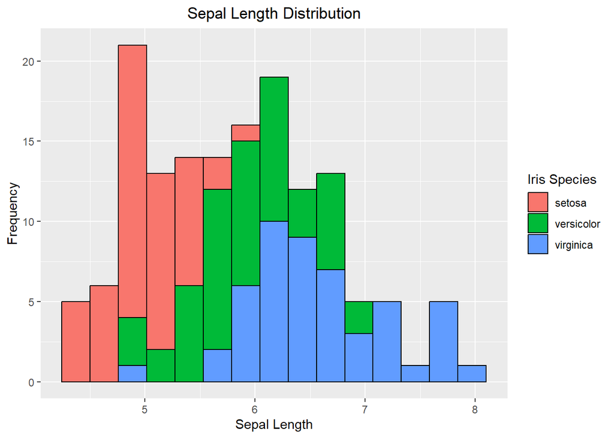

```r
# Generate histogram
hist_1 <- iris %>%
  ggplot(., aes(x = `Sepal(L)`, fill = `Iris Species`)) +
  geom_histogram(color = 'black', bins = 15) +
  labs(title = "Sepal Length Distribution", x = "Sepal Length", y = "Frequency") +
  theme(plot.title = element_text(hjust = 0.5))

# Display histogram
print(hist_1)
```

Analysis : Generally, the sepal length has the characteristics of a normal distribution with slightly positive skew, because the right tail is longer than the left tail. Based on the analysis, we can get the insight that the majority of the iris flowers has the sepal length concentrated around 5.0 to 6.3. But if we categorize it based on its species, we can find that each species has their own characteristics. The setosa species has shorter sepal than the others, while virginica has the longest sepals.

#### “Sepal(W)” Column

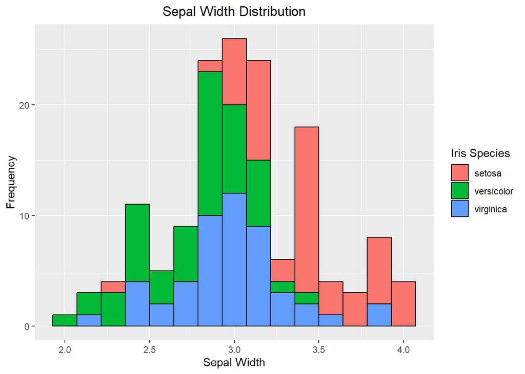

```r
# Generate histogram
hist_2 <- iris %>%
  ggplot(., aes(x = `Sepal(W)`, fill = `Iris Species`)) +
  geom_histogram(color = 'black', bins = 15) +
  labs(title = "Sepal Width Distribution", x = "Sepal Width", y = "Frequency") +
  theme(plot.title = element_text(hjust = 0.5))

# Display histogram
print(hist_2)
```

Analysis : In general, the sepal width has a Gaussian or normal distribution, because the data are mostly clustered in the middle, with the peak around 3.0. This suggests that the sepal width of the iris flowers are majorly distributed around the mean value, 3.0. But based on their species, setosa species has the widest sepals.

#### “Petal(L)” Column

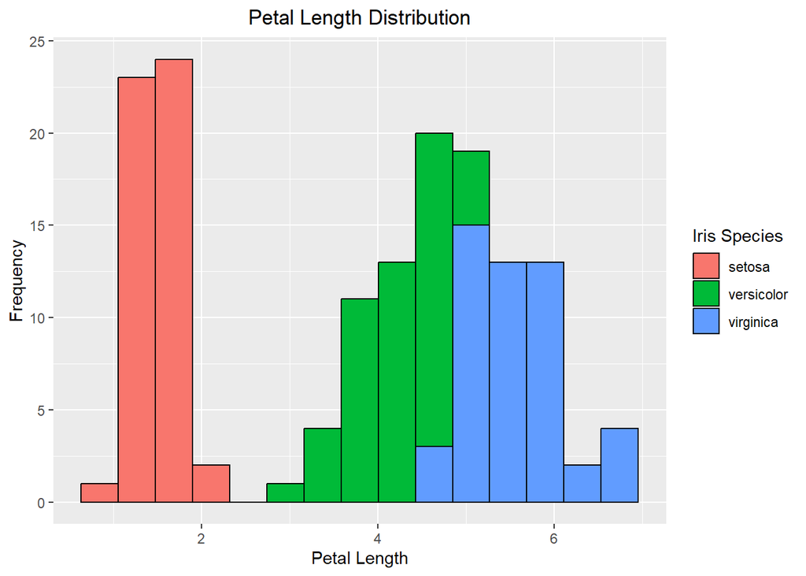

```r
# Generate histogram
hist_3 <- iris %>%
  ggplot(., aes(x = `Petal(L)`, fill = `Iris Species`)) +
  geom_histogram(color = 'black', bins = 15) +
  labs(title = "Petal Length Distribution", x = "Petal Length", y = "Frequency") +
  theme(plot.title = element_text(hjust = 0.5))

# Display histogram
print(hist_3)
```

Analysis : The petal length column has bi-modal distribution, characterized by two distinct peaks. This distribution represents that there are two different characteristics or species between the iris flowers, that the majority of the iris flowers has the petal length concentrated either around 1.5 or around 5.0. However, based on its species, the setosa species has the shortest petals, while the virginica has the longest petals.

#### “Petal(W)” Column

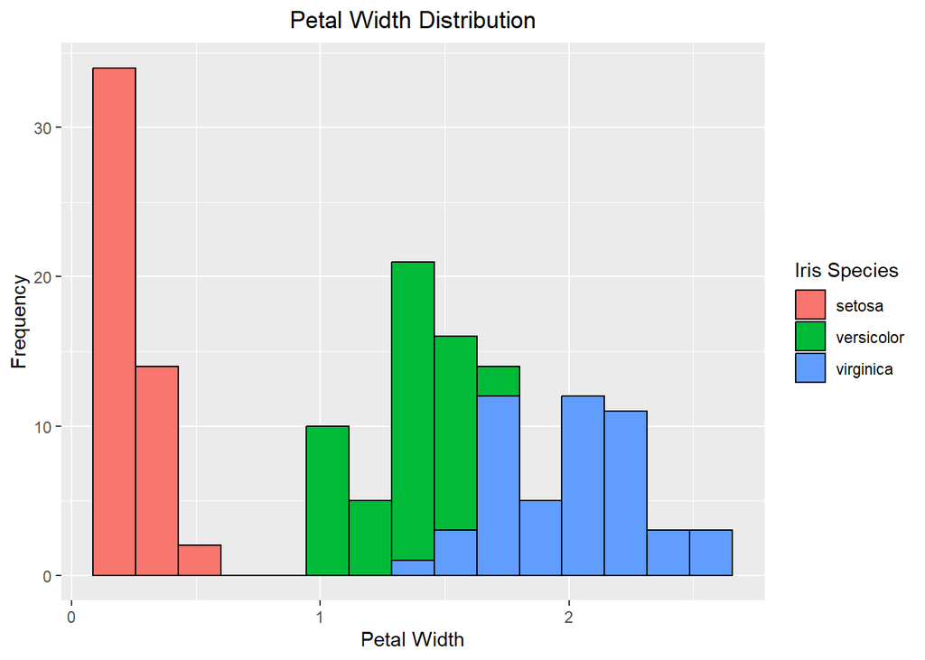

```r
# Generate histogram
hist_4 <- iris %>%
  ggplot(., aes(x = `Petal(W)`, fill = `Iris Species`)) +
  geom_histogram(color = 'black', bins = 15) +
  labs(title = "Petal Width Distribution", x = "Petal Width", y = "Frequency") +
  theme(plot.title = element_text(hjust = 0.5))

# Display histogram
print(hist_4)
```

#### SCATTER PLOTS

In the code below, I use scatter plots to determine the correlation between sepal length and width, petal length and width, sepal and petal length, and sepal and petal width. In order to do that, I use the geom_point() function and ggplot() function as I set the x-axis to represent the first column and the y-axis to represent the second column, I also categorize them based on their species inside the aes() function.

#### “Sepal(L)” Column and “Sepal(W)” Column

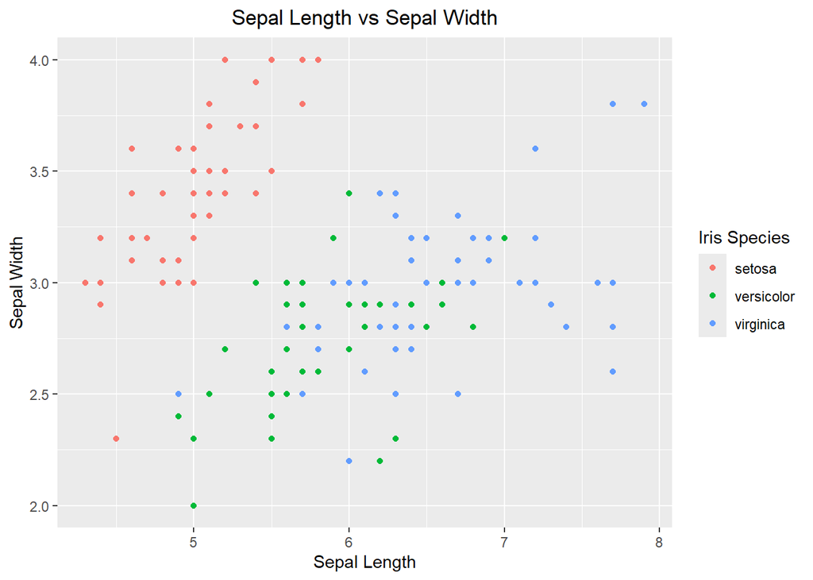

```r
# Generate scatter plot
splot_slsw <- iris %>%
  ggplot(., aes(x = `Sepal(L)`, y = `Sepal(W)`, color = `Iris Species`)) +
  geom_point() +
  labs(title = "Sepal Length vs Sepal Width", x = "Sepal Length", y = "Sepal Width") +
  theme(plot.title = element_text(hjust = 0.5))

# Display the scatter plot
print(splot_slsw)
```

Analysis : The sepal length and sepal width column has no correlation as the data points are randomly scattered. This indicates that knowing the sepal length of an iris flower can’t give any information about its sepal width.

#### “Petal(L)” Column and “Petal(W)” Column

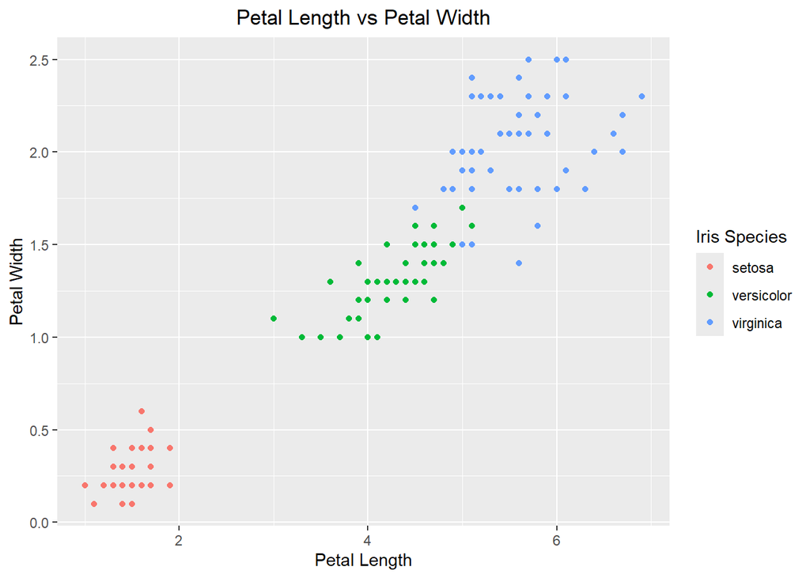

```r
# Generate scatter plot
splot_plpw <- iris %>%
  ggplot(., aes(x = `Petal(L)`, y = `Petal(W)`, color = `Iris Species`)) +
  geom_point() +
  labs(title = "Petal Length vs Petal Width", x = "Petal Length", y = "Petal Width") +
  theme(plot.title = element_text(hjust = 0.5))

# Display the scatter plot
print(splot_plpw)
```

Analysis : Based on the scatter plot, the petal length and petal width of iris flower are strongly correlated and directly proportional, because the trend is increasing and the data points are focused on a straight line, means that the longer the petal of an iris, the wider its petal will be.

#### “Sepal(L)” Column and “Petal(L)” Column

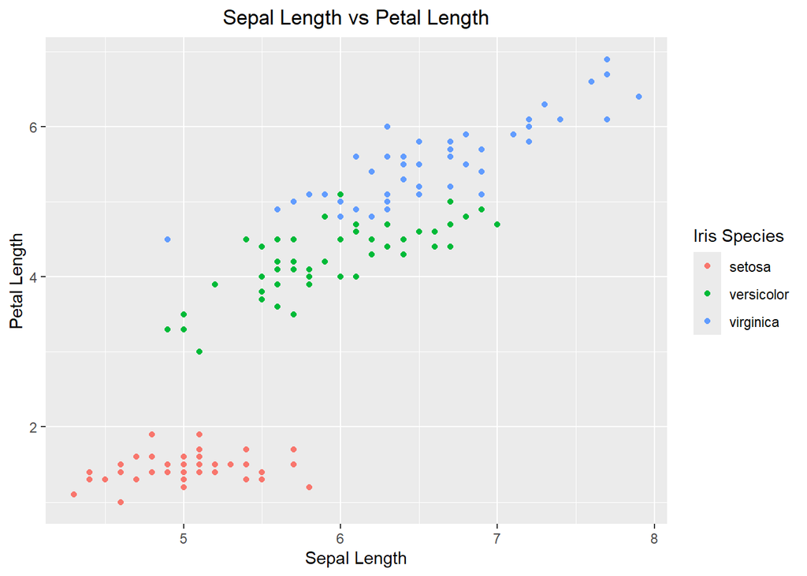

```r
# Generate scatter plot
splot_slpl <- iris %>%
  ggplot(., aes(x = `Sepal(L)`, y = `Petal(L)`, color = `Iris Species`)) +
  geom_point() +
  labs(title = "Sepal Length vs Petal Length", x = "Sepal Length", y = "Petal Length") +
  theme(plot.title = element_text(hjust = 0.5))

# Display the scatter plot
print(splot_slpl)
```

Analysis : The sepal length and petal length of iris flowers are also strongly correlated and directly proportional. The trend is also increasing and the data points are focused on a straight line, suggests that the longer the sepal of an iris, the longer its petal will be.

#### “Sepal(W)” Column and “Petal(W)” Column

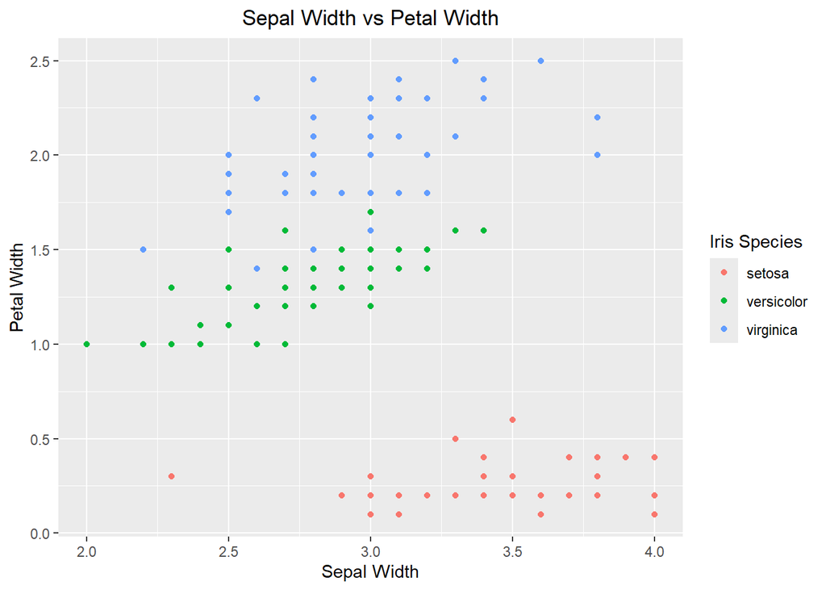

```r
# Generate scatter plot
splot_swpw <- iris %>%
  ggplot(., aes(x = `Sepal(W)`, y = `Petal(W)`, color = `Iris Species`)) +
  geom_point() +
  labs(title = "Sepal Width vs Petal Width", x = "Sepal Width", y = "Petal Width") +
  theme(plot.title = element_text(hjust = 0.5))

# Display the scatter plot
print(splot_swpw)
```

### CORRELATION ANALYSIS

```r
# Check Normality of Each Column
shapiro.test(iris$`Sepal(L)`)
```

```
##
##  Shapiro-Wilk normality test
##
## data:  iris$`Sepal(L)`
## W = 0.97609, p-value = 0.01018
```

```r
shapiro.test(iris$`Sepal(W)`)
```

```
##
##  Shapiro-Wilk normality test
##
## data:  iris$`Sepal(W)`
## W = 0.98339, p-value = 0.0676
```

```r
shapiro.test(iris$`Petal(L)`)
```

```
##
##  Shapiro-Wilk normality test
##
## data:  iris$`Petal(L)`
## W = 0.87627, p-value = 7.412e-10
```

```r
shapiro.test(iris$`Petal(W)`)
```

```
##
##  Shapiro-Wilk normality test
##
## data:  iris$`Petal(W)`
## W = 0.90183, p-value = 1.68e-08
```

```r
# Normalize the Sepal Length Column
iris$`Sepal(L)`
```

```
##   [1] 5.1 4.9 4.7 4.6 5.0 5.4 4.6 5.0 4.4 4.9 5.4 4.8 4.8 4.3 5.8 5.7 5.4 5.1
##  [19] 5.7 5.1 5.4 5.1 4.6 5.1 4.8 5.0 5.0 5.2 5.2 4.7 4.8 5.4 5.2 5.5 4.9 5.0
##  [37] 5.5 4.9 4.4 5.1 5.0 4.5 4.4 5.0 5.1 4.8 5.1 4.6 5.3 5.0 7.0 6.4 6.9 5.5
##  [55] 6.5 5.7 6.3 4.9 6.6 5.2 5.0 5.9 6.0 6.1 5.6 6.7 5.6 5.8 6.2 5.6 5.9 6.1
##  [73] 6.3 6.1 6.4 6.6 6.8 6.7 6.0 5.7 5.5 5.5 5.8 6.0 5.4 6.0 6.7 6.3 5.6 5.5
##  [91] 5.5 6.1 5.8 5.0 5.6 5.7 5.7 6.2 5.1 5.7 6.3 5.8 7.1 6.3 6.5 7.6 4.9 7.3
## [109] 6.7 7.2 6.5 6.4 6.8 5.7 5.8 6.4 6.5 7.7 7.7 6.0 6.9 5.6 7.7 6.3 6.7 7.2
## [127] 6.2 6.1 6.4 7.2 7.4 7.9 6.4 6.3 6.1 7.7 6.3 6.4 6.0 6.9 6.7 6.9 5.8 6.8
## [145] 6.7 6.7 6.3 6.5 6.2 5.9
```

```r
iris$`Sepal(L)` <- scale(iris$`Sepal(L)`) %>%
  round(., digits = 1)

# Normalize the Petal Length Column
iris$`Petal(L)`
```

```
##   [1] 1.4 1.4 1.3 1.5 1.4 1.7 1.4 1.5 1.4 1.5 1.5 1.6 1.4 1.1 1.2 1.5 1.3 1.4
##  [19] 1.7 1.5 1.7 1.5 1.0 1.7 1.9 1.6 1.6 1.5 1.4 1.6 1.6 1.5 1.5 1.4 1.5 1.2
##  [37] 1.3 1.4 1.3 1.5 1.3 1.3 1.3 1.6 1.9 1.4 1.6 1.4 1.5 1.4 4.7 4.5 4.9 4.0
##  [55] 4.6 4.5 4.7 3.3 4.6 3.9 3.5 4.2 4.0 4.7 3.6 4.4 4.5 4.1 4.5 3.9 4.8 4.0
##  [73] 4.9 4.7 4.3 4.4 4.8 5.0 4.5 3.5 3.8 3.7 3.9 5.1 4.5 4.5 4.7 4.4 4.1 4.0
##  [91] 4.4 4.6 4.0 3.3 4.2 4.2 4.2 4.3 3.0 4.1 6.0 5.1 5.9 5.6 5.8 6.6 4.5 6.3
## [109] 5.8 6.1 5.1 5.3 5.5 5.0 5.1 5.3 5.5 6.7 6.9 5.0 5.7 4.9 6.7 4.9 5.7 6.0
## [127] 4.8 4.9 5.6 5.8 6.1 6.4 5.6 5.1 5.6 6.1 5.6 5.5 4.8 5.4 5.6 5.1 5.1 5.9
## [145] 5.7 5.2 5.0 5.2 5.4 5.1
```

```r
iris$`Petal(L)` <- scale(iris$`Petal(L)`) %>%
  round(., digits = 1)

# Normalize the Petal Width Column
iris$`Petal(W)`
```

```
##   [1] 0.2 0.2 0.2 0.2 0.2 0.4 0.3 0.2 0.2 0.1 0.2 0.2 0.1 0.1 0.2 0.4 0.4 0.3
##  [19] 0.3 0.3 0.2 0.4 0.2 0.5 0.2 0.2 0.4 0.2 0.2 0.2 0.2 0.4 0.1 0.2 0.2 0.2
##  [37] 0.2 0.1 0.2 0.2 0.3 0.3 0.2 0.6 0.4 0.3 0.2 0.2 0.2 0.2 1.4 1.5 1.5 1.3
##  [55] 1.5 1.3 1.6 1.0 1.3 1.4 1.0 1.5 1.0 1.4 1.3 1.4 1.5 1.0 1.5 1.1 1.8 1.3
##  [73] 1.5 1.2 1.3 1.4 1.4 1.7 1.5 1.0 1.1 1.0 1.2 1.6 1.5 1.6 1.5 1.3 1.3 1.3
##  [91] 1.2 1.4 1.2 1.0 1.3 1.2 1.3 1.3 1.1 1.3 2.5 1.9 2.1 1.8 2.2 2.1 1.7 1.8
## [109] 1.8 2.5 2.0 1.9 2.1 2.0 2.4 2.3 1.8 2.2 2.3 1.5 2.3 2.0 2.0 1.8 2.1 1.8
## [127] 1.8 1.8 2.1 1.6 1.9 2.0 2.2 1.5 1.4 2.3 2.4 1.8 1.8 2.1 2.4 2.3 1.9 2.3
## [145] 2.5 2.3 1.9 2.0 2.3 1.8
```

```r
iris$`Petal(W)` <- scale(iris$`Petal(W)`) %>%
  round(., digits = 1)
```

Analysis : Based on the normality test, we can get that only the Sepal Width column is normally distributed. So, we need to perform normalization on the Sepal Length, Petal Length, and Petal Width columns.

#### “Sepal(L)” Column and “Sepal(W)” Column

```r
# Test the correlation
slsw <- cor.test(iris$`Sepal(L)`, iris$`Sepal(W)`, method = "pearson")

# Display the correlation coefficient
print(slsw$estimate)
```

```
##        cor
## -0.1189381
```

#### “Petal(L)” Column and “Petal(W)” Column

```r
# Test the correlation
plpw <- cor.test(iris$`Petal(L)`, iris$`Petal(W)`, method = "pearson")

# Display the correlation coefficient
print(plpw$estimate)
```

```
##      cor
## 0.961609
```

#### “Sepal(L)” Column and “Petal(L)” Column

```r
# Test the correlation
slpl <- cor.test(iris$`Sepal(L)`, iris$`Petal(L)`, method = "pearson")

# Display the correlation coefficient
print(slpl$estimate)
```

```
##       cor
## 0.8715004
```

#### “Sepal(W)” Column and “Petal(W)” Column

```r
# Test the correlation
swpw <- cor.test(iris$`Sepal(W)`, iris$`Petal(W)`, method = "pearson")

# Display the correlation coefficient
print(swpw$estimate)
```

```
##        cor
## -0.3571369
```

### LINEAR REGRESSION MODEL

Linear Regression Model : y = a + b1x1 + b2x2

```r
# Perform linear regression
linearreg <- iris %>%
  lm(formula = `Sepal(L)` ~ `Petal(L)` + `Petal(W)`, .)

# Display the summary
print(summary(linearreg))
```

```
##
## Call:
## lm(formula = `Sepal(L)` ~ `Petal(L)` + `Petal(W)`, data = .)
##
## Residuals:
##      Min       1Q   Median       3Q      Max
## -1.37374 -0.38340  0.01161  0.35190  1.12656
##
## Coefficients:
##              Estimate Std. Error t value Pr(>|t|)
## (Intercept)  0.001558   0.039837   0.039    0.969
## `Petal(L)`   1.099665   0.145844   7.540 4.47e-12 ***
## `Petal(W)`  -0.239546   0.146393  -1.636    0.104
## ---
## Signif. codes:  0 '***' 0.001 '**' 0.01 '*' 0.05 '.' 0.1 ' ' 1
##
## Residual standard error: 0.4879 on 147 degrees of freedom
## Multiple R-squared:  0.7638, Adjusted R-squared:  0.7606
## F-statistic: 237.7 on 2 and 147 DF,  p-value: < 2.2e-16
```

To verify my analysis, I also made the plot for the regression model using the geom_point() and ggplot() function as I set the x-axis to represent the independent variable and the y-axis to represent the response variable inside the aes() function.

#### Sepal Length and Petal Length

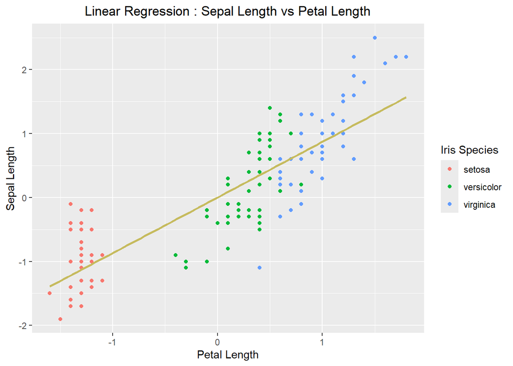

```r
reg_slpl <- iris %>%
  ggplot(., aes(x = `Petal(L)`, y = `Sepal(L)`, color = `Iris Species`)) +
  geom_point() +
  geom_smooth(method = "lm", se = FALSE, color = '#C6BB5E') +
  labs(title = "Linear Regression : Sepal Length vs Petal Length", x = "Petal Length", y = "Sepal Length") +
  theme(plot.title = element_text(hjust = 0.5))

# Display the regression plot
print(reg_slpl)
```

Analysis : Based on the regression plot, it is implied that the sepal length is linear to the petal length. Which indicates that the longer the petal of the iris flower, the longer the sepal is.

#### Sepal Length and Petal Width

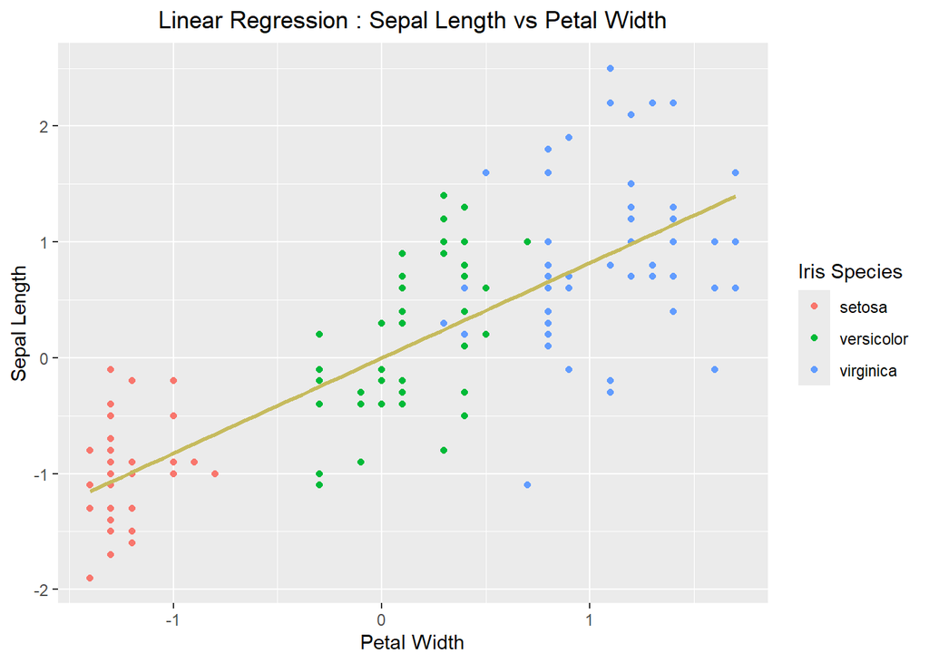

```r
reg_slpw <- iris %>%
  ggplot(., aes(x = `Petal(W)`, y = `Sepal(L)`, color = `Iris Species`)) +
  geom_point() +
  geom_smooth(method = "lm", se = FALSE, color = '#C6BB5E') +
  labs(title = "Linear Regression : Sepal Length vs Petal Width", x = "Petal Width", y = "Sepal Length") +
  theme(plot.title = element_text(hjust = 0.5))

# Display the regression plot
print(reg_slpw)
```

Analysis : Based on the regression plot, it is implied that the sepal length is also linear to the petal width. Which indicates that the wider the petal of the iris flower, the longer the sepal is.

### HYPOTHESIS TESTING

To perform hypothesis testing based on the linear regression model, I use the slicing method of the coefficient summary of the lm() function.

```r
# Slice the p-value from the summary
pl_p_value <- summary(linearreg)$coefficients["`Petal(L)`", "Pr(>|t|)"]

# Display the p-value
print(pl_p_value)
```

```
## [1] 4.474778e-12
```